# Retail Project

Xiyun Zhou

19/05/2021

## You should produce forecasts of the series using ETS and ARIMA models. Write a report in Rmarkdown format of your analysis explaining carefully what you have done and why you have done it. Your report should include the following elements.

```r
set.seed(29827299)
myseries <- aus_retail %>%
  filter(
    `Series ID` == sample(aus_retail$`Series ID`,1),
    Month < yearmonth("2018 Jan")
  )

myseries <- myseries %>%
  select(-State, -Industry)
```

1. A discussion of the statistical features of the original data.

## The data shows Australian monthly retail trade turnover through time series. It is clear to see that the data features a non-linear upward trend, and a strong seasonal pattern occurs as well. We can see the seasonal pattern, that the highest point always occurs in December and the lowest turnover seems shown in Feburary. There is no certain pattern of cyclical. The variability in the data appears proportional to the amount of turnover (level of the series) over the time period.The data also seems like have heteroskedasticity, since the variance changes over the time. Besides, the ACF plot shows a strong autocorrelations of the data, especialy in seasonal lags, such as lag 12,24…

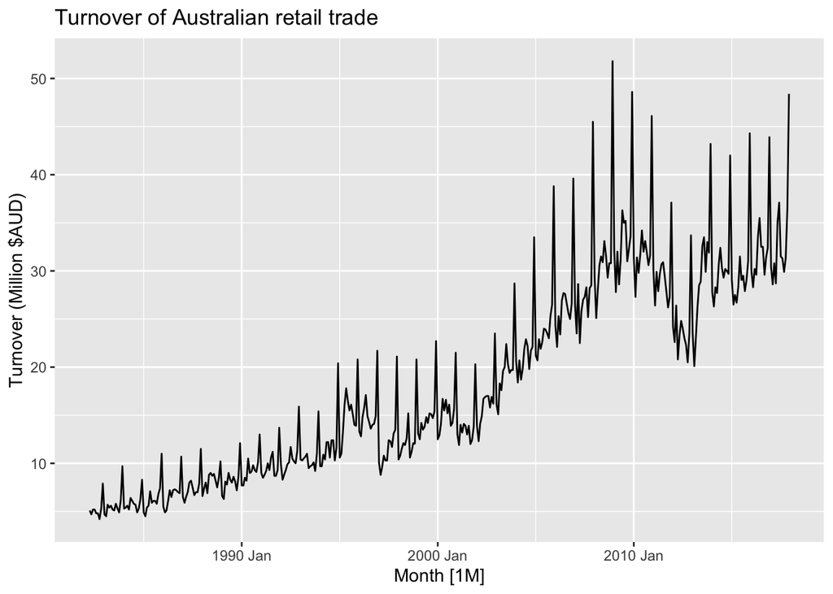

```r
myseries %>%
  autoplot(Turnover) +
  ggtitle("Turnover of Australian retail trade") +
  ylab("Turnover (Million $AUD)")
```

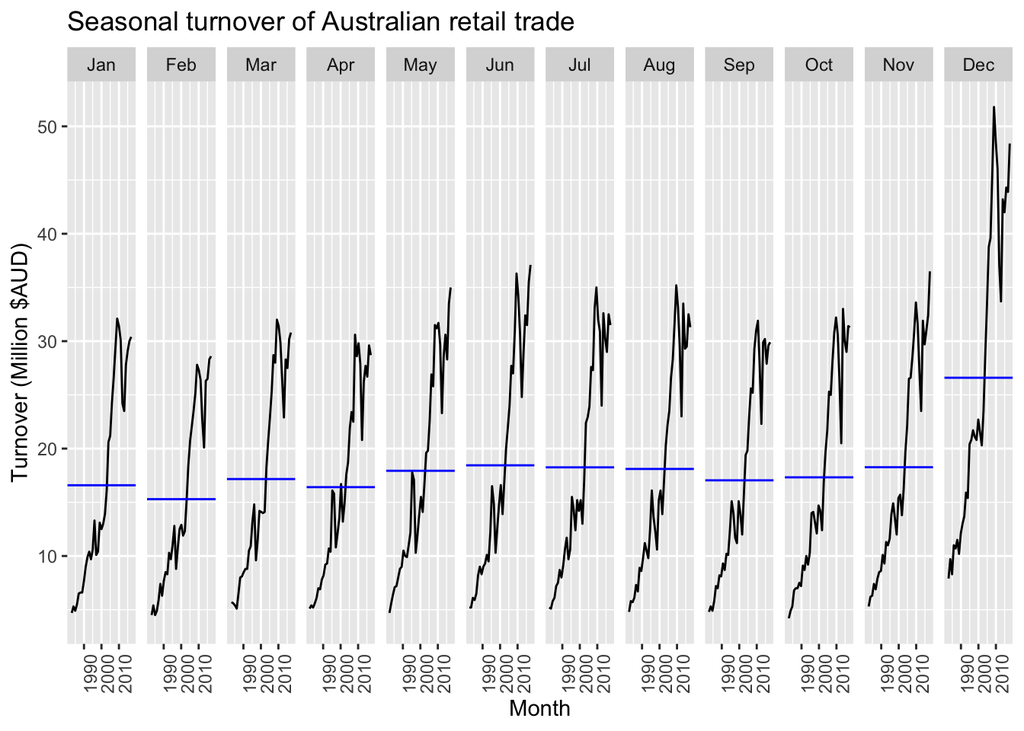

```r
myseries %>%
  gg_subseries(Turnover) +
  ggtitle("Seasonal turnover of Australian retail trade") +
  ylab("Turnover (Million $AUD)")
```

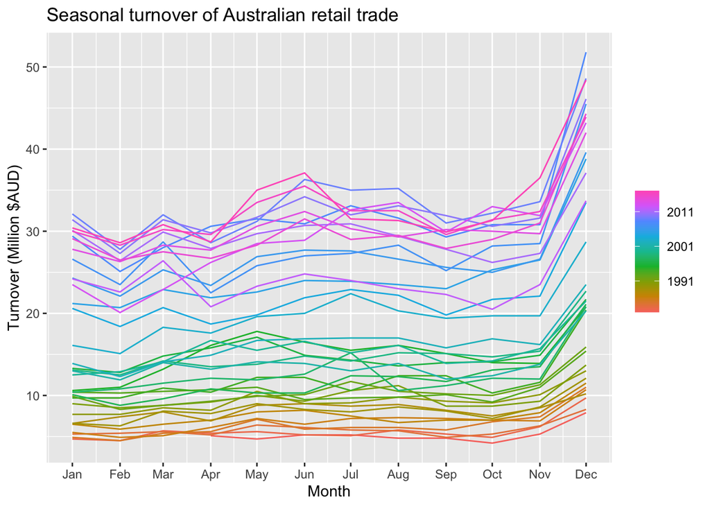

```r
myseries %>%
  gg_season(Turnover) +
            ggtitle("Seasonal turnover of Australian retail trade") +
           ylab("Turnover (Million $AUD)")
```

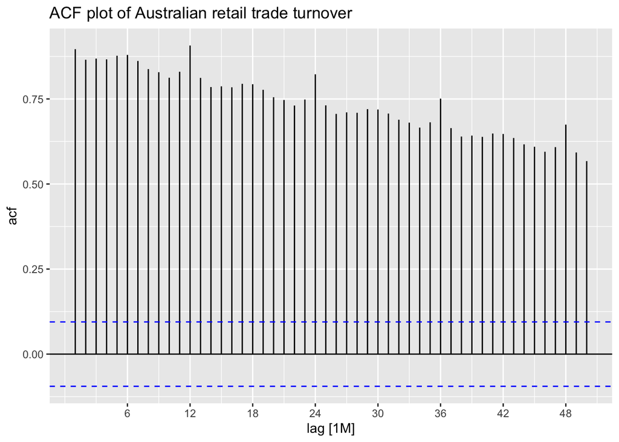

```r
myseries %>%
  ACF(Turnover, lag_max = 50) %>%
  autoplot() +
  ggtitle("ACF plot of Australian retail trade turnover")
```

2. Explanation of transformations and differencing used. You should use a unit-root test as part of the discussion.

##Because the data shows variation that increases or decreases with the level of the series. Log transformation is useful and interpretable.  
The box_cox transformation is attempts to balance the seasonal fluctuations and random variation across the seris.

By doing the unitroot test, to check whether the first two transformations made data stationary. The null hypothesis is that the data are stationary and non-seasonal. The result of unitroot test of the two transformation both shows P-value is 0.01, which is smaller than 5% significant level. That we can reject the null hypothesis, the data is non-stationary and seasonal.That means the log and box_cox transformation is not enough.

By checking unitroot_nsdiffs, which gives the minimal number of seasonal differences required to make a series stationary. The result shows we need do 1 time of differencing. Then we check the seasonal strength is 0.8438667, greater than 0.64. It indicates one seasonal differencing should be done. After that doing one seasonal differencing, followed by checking whether we need more differencing. The result shows no need to do further differencing. Dbouble check using unitroot test. P-value is 0.1 >5%, that we cannot reject null hypothesis, the data is stationary and non-seasonal.

```r
myseries %>%
  features(Turnover, features = guerrero)
```

```
## # A tibble: 1 x 2
##   lambda_guerrero .name_repair
##             <dbl> <chr>
## 1           0.121 minimal
```

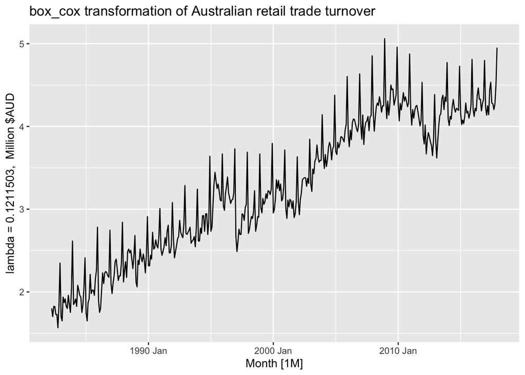

```r
#automatically choose suitable lambda

#box_cox transformation
myseries %>%
  autoplot(box_cox(Turnover, 0.1211503  )) +
  ggtitle("box_cox transformation of Australian retail trade turnover") +
  ylab("lambda = 0.1211503,  Million $AUD")
```

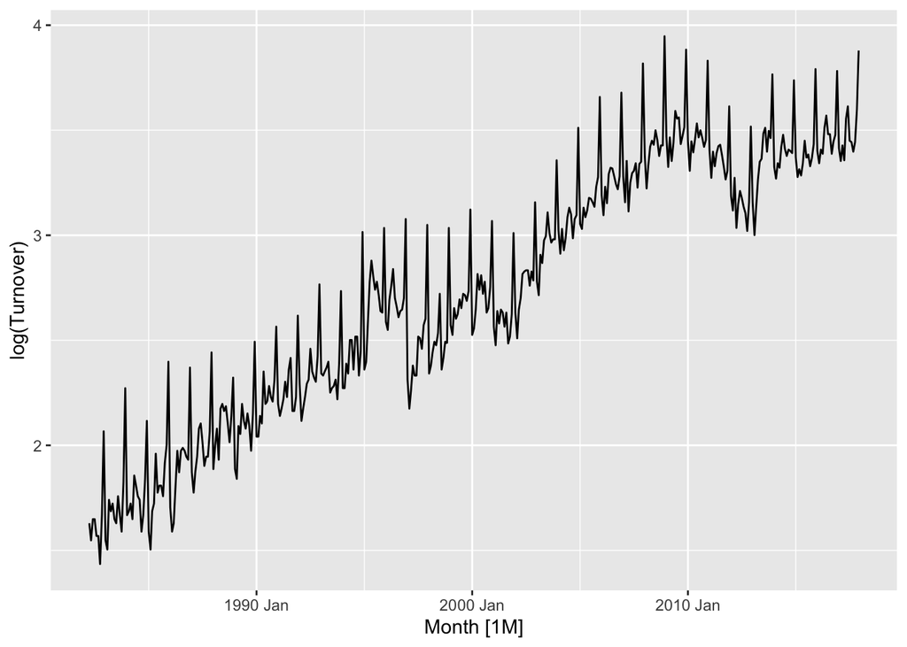

```r
#log transformation
myseries %>%
  autoplot(log(Turnover))
```

```r
#unitroot test
myseries %>%
  features(box_cox(Turnover,0.1211503 ), unitroot_kpss)
```

```
## # A tibble: 1 x 3
##   kpss_stat kpss_pvalue .name_repair
##       <dbl>       <dbl> <chr>
## 1      6.97        0.01 minimal
```

```r
myseries %>%
  features(log(Turnover), unitroot_kpss)
```

```
## # A tibble: 1 x 3
##   kpss_stat kpss_pvalue .name_repair
##       <dbl>       <dbl> <chr>
## 1      6.95        0.01 minimal
```

```r
myseries %>%
  features(log(Turnover), list(unitroot_nsdiffs, feat_stl))
```

```
## # A tibble: 1 x 11
##   nsdiffs trend_strength seasonal_streng… seasonal_peak_y… seasonal_trough…
##     <int>          <dbl>            <dbl>            <dbl>            <dbl>
## 1       1          0.991            0.844                9               11
## # … with 6 more variables: spikiness <dbl>, linearity <dbl>, curvature <dbl>,
## #   stl_e_acf1 <dbl>, stl_e_acf10 <dbl>, .name_repair <chr>
```

```r
myseries %>%
  features(difference(log(Turnover), 12), unitroot_ndiffs)
```

```
## # A tibble: 1 x 2
##   ndiffs .name_repair
##    <int> <chr>
## 1      0 minimal
```

```r
myseries %>%
  features(difference(log(Turnover), 12), unitroot_kpss)
```

```
## # A tibble: 1 x 3
##   kpss_stat kpss_pvalue .name_repair
##       <dbl>       <dbl> <chr>
## 1     0.205         0.1 minimal
```

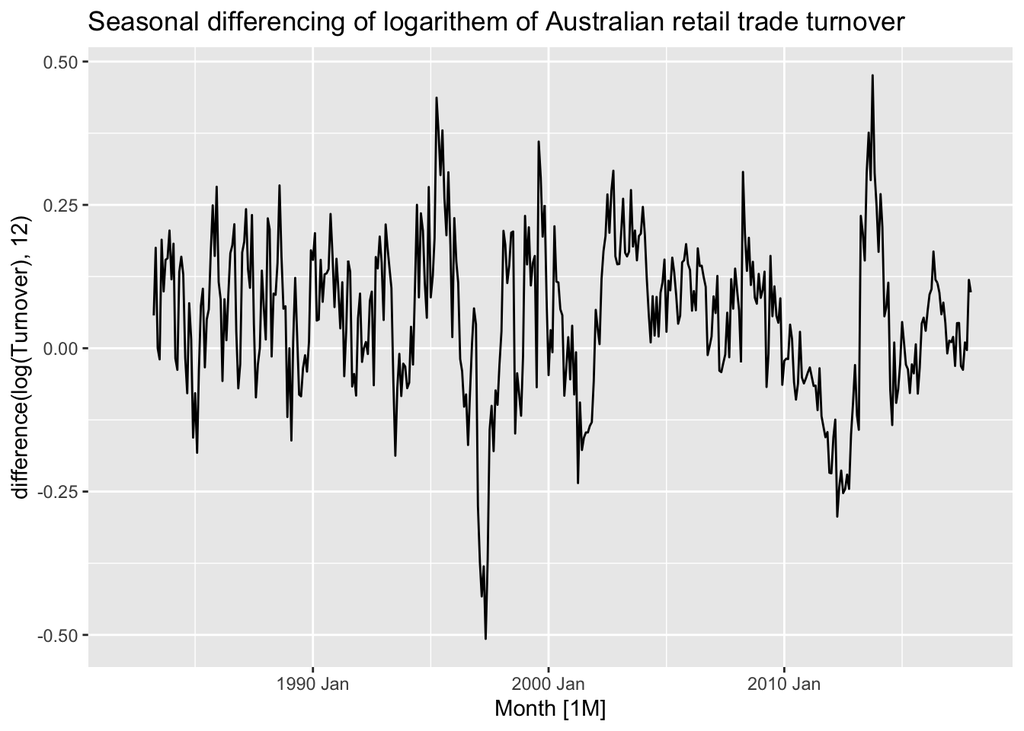

```r
myseries %>%
  autoplot(difference(log(Turnover), 12)) +
  ggtitle("Seasonal differencing of logarithem of Australian retail trade turnover")
```

3. A description of the methodology used to create a short-list of appropriate ARIMA models and ETS models. Include discussion of AIC values as well as results from applying the models to a test-set consisting of the last 24 months of data provided.

###For the shortlist for ETS models: According to the time series plot of the origin data do have trend and seasonality, the parameter for “trend” and “season” should not be N (none).Then if the “trend” component is a multiplicative form, it will give a quadratic result.Besides, models with multiplicative errors are useful for strictly positive data, but are numerically stable with data containing zeros or negative values. That we cannot choose ETS component as addictive “Error” with multiplicative “season”. By using restrictions above, we should try ETS models as, Addictive Error: ETS(A,A,A) ETS(A,Ad,A) Multiplicative Error: ETS(M,A,A) ETS(M,A,M) ETS(M,Ad,A) ETS(M,Ad,M). In conclusion, the shortlist of ETS model have six models that we can try.

By comparing AIC and AICc values in the shortlist, following Akaike’s information criteria, model ETS(M,A,M) have the smallest AIC and AICc, and the maximum likelihood value for the training data.

For the test-set, the accuracy of forecasting 2 years data shows that model ETS(A,A,A) gives the smallest RMSE and MAE value. The result of forecasting accuracy and AIC method have different results.

However, I will go for ETS(M,A,M), because it is give the maximum likelihood and minimising the AIC value in training data and it is also a longer term detecting in training data than test data.

```r
train <- myseries %>%
  slice(1: (n() -24))

test <- myseries %>%
  slice((n() -23) :n())

list_ETS <- train %>%
  model(AAA =  ETS(Turnover ~ error('A')+trend('A')+season('A')),
        AAdA = ETS(Turnover ~ error('A')+trend('Ad')+season('A')),
        MAA =  ETS(Turnover ~ error('M')+trend('A')+season('A')),
        MAM =  ETS(Turnover ~ error('M')+trend('A')+season('M')),
        MAdA = ETS(Turnover ~ error('M')+trend('Ad')+season('A')),
        MAdM = ETS(Turnover ~ error('M')+trend('Ad')+season('M')),
      )

list_ETS %>%
  glance()
```

```
## # A tibble: 6 x 9
##   .model  sigma2 log_lik   AIC  AICc   BIC   MSE  AMSE    MAE
##   <chr>    <dbl>   <dbl> <dbl> <dbl> <dbl> <dbl> <dbl>  <dbl>
## 1 AAA    2.28     -1375. 2784. 2785. 2852.  2.19  2.78 1.02
## 2 AAdA   2.27     -1373. 2782. 2783. 2854.  2.17  2.82 1.03
## 3 MAA    0.00756  -1307. 2648. 2649. 2716.  2.18  2.76 0.0639
## 4 MAM    0.00576  -1250. 2534. 2535. 2602.  1.60  2.12 0.0570
## 5 MAdA   0.00835  -1320. 2677. 2679. 2749.  2.18  2.77 0.0669
## 6 MAdM   0.00595  -1253. 2541. 2543. 2613.  1.60  2.14 0.0577
```

```r
##Check the performance of the model forecasting
list_ETS %>%
  forecast(h = '2 years') %>%
accuracy(test)
```

```
## # A tibble: 6 x 10
##   .model .type      ME  RMSE   MAE    MPE  MAPE  MASE RMSSE   ACF1
##   <chr>  <chr>   <dbl> <dbl> <dbl>  <dbl> <dbl> <dbl> <dbl>  <dbl>
## 1 AAA    Test   0.202   1.61  1.23  0.296  3.62   NaN   NaN 0.333
## 2 AAdA   Test   0.992   1.94  1.32  2.68   3.76   NaN   NaN 0.341
## 3 MAA    Test  -0.0237  1.66  1.35 -0.336  4.07   NaN   NaN 0.362
## 4 MAdA   Test   1.28    2.10  1.50  3.59   4.31   NaN   NaN 0.332
## 5 MAdM   Test   2.05    2.60  2.10  6.11   6.24   NaN   NaN 0.173
## 6 MAM    Test   1.16    1.96  1.63  3.52   4.88   NaN   NaN 0.0860
```

## ARIMA model:

After finishing seasonal differenceing in the question 2, plot the ACF and PACF. To decide the parameter of p,q in the non-seasonal part in ARIMA model, the ACF plot shows the line damped sine-wave manner. The PACF has almost zero spikes (except seasonal lags) beyond 2nd spike. Because to keep the models relatively simple, I would not look past about 5 or 6 non-seasonal lags. Then, choose p =2, AR(2). For the order of MA, we not sure about the value of q. Because there are only fewer non-spikes of ACF. We can try q = 0,1,2.

In the seasonal part of ARIMA model, the 12th lag of ACF and PACF are spikes. And the 24th of lag is also spike in ACF. We can try P=1, Q =1,2. The seasonal differencing is in seasonal part.

Furthermore, the origin time series plot has an upward trend, that I decide to add constant component in the ARIMA model.

Therefore, the short-list for ARIMA model can be conducted: ARIMA(2,0,0)(1,1,1)+drift ARIMA(2,0,0)(1,1,2)+drift ARIMA(2,0,1)(1,1,1)+drift ARIMA(2,0,1)(1,1,2)+drift ARIMA(2,0,2)(1,1,1)+drift ARIMA(2,0,2)(1,1,2)+drift

Following the rule of minimising AIC and AICc, I would choose ARIMA(2,0,1)(1,1,1), which gives the smallest AIC and AICc.

Looking at the accuracy results for the 2 years forecasting, which is good to see that the ARIMA(2,0,1)(1,1,1) also gives the smallest RMSE and MAE value.

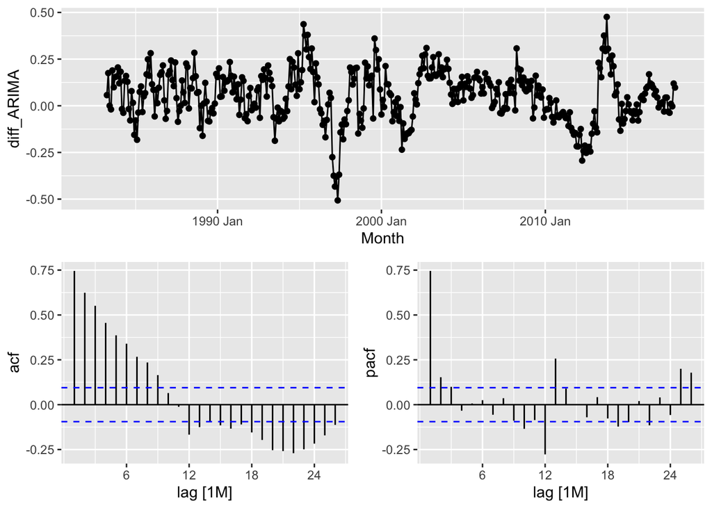

```r
diff_ARIMA <- log(myseries$Turnover) %>% difference(12)

myseries %>%
gg_tsdisplay(diff_ARIMA, plot_type = "partial")
```

```r
list_ARIMA <- train %>%
  model(arima200111 = ARIMA(log(Turnover) ~ 1+pdq(2,0,0) +PDQ(1,1,1)),
        arima200112 = ARIMA(log(Turnover) ~ 1+pdq(2,0,0) +PDQ(1,1,2)),
        arima201111 = ARIMA(log(Turnover) ~ 1+pdq(2,0,1) +PDQ(1,1,1)),
        arima201112 = ARIMA(log(Turnover) ~ 1+pdq(2,0,1) +PDQ(1,1,2)),
        arima202111 = ARIMA(log(Turnover) ~ 1+pdq(2,0,2) +PDQ(1,1,1)),
        arima202112 = ARIMA(log(Turnover) ~ 1+pdq(2,0,2) +PDQ(1,1,2)))
list_ARIMA %>%
  glance()
```

```
## # A tibble: 6 x 8
##   .model       sigma2 log_lik   AIC  AICc   BIC ar_roots   ma_roots
##   <chr>         <dbl>   <dbl> <dbl> <dbl> <dbl> <list>     <list>
## 1 arima200111 0.00583    447. -882. -882. -858. <cpl [14]> <cpl [12]>
## 2 arima200112 0.00585    447. -880. -880. -852. <cpl [14]> <cpl [24]>
## 3 arima201111 0.00570    452. -890. -890. -862. <cpl [14]> <cpl [13]>
## 4 arima201112 0.00571    452. -888. -888. -856. <cpl [14]> <cpl [25]>
## 5 arima202111 0.00569    453. -889. -889. -858. <cpl [14]> <cpl [14]>
## 6 arima202112 0.00570    453. -887. -887. -852. <cpl [14]> <cpl [26]>
```

```r
list_ARIMA %>%
  forecast(h = "2 years") %>%
  accuracy(test)
```

```
## # A tibble: 6 x 10
##   .model      .type    ME  RMSE   MAE    MPE  MAPE  MASE RMSSE  ACF1
##   <chr>       <chr> <dbl> <dbl> <dbl>  <dbl> <dbl> <dbl> <dbl> <dbl>
## 1 arima200111 Test  -3.87  5.00  4.02 -11.6  12.0    NaN   NaN 0.533
## 2 arima200112 Test  -3.87  5.00  4.02 -11.6  12.0    NaN   NaN 0.533
## 3 arima201111 Test  -2.39  3.63  2.80  -7.07  8.38   NaN   NaN 0.486
## 4 arima201112 Test  -2.39  3.63  2.81  -7.08  8.39   NaN   NaN 0.487
## 5 arima202111 Test  -2.57  3.79  2.95  -7.61  8.81   NaN   NaN 0.492
## 6 arima202112 Test  -2.58  3.81  2.97  -7.66  8.86   NaN   NaN 0.494
```

4. Choose one ARIMA model and one ETS model based on this analysis and show parameter estimates, residual diagnostics, forecasts and prediction intervals for both models. Diagnostic checking for both models should include ACF graphs as well as the Ljung-Box test.

###For the fitted ETS model, I choose ETS(M,A,M), which have the smallest AIC and AICc. For the ARIMA model, I choose ARIMA(2,0,1)(1,1,1) with constant part, which not only gives the minimising AIC and AICc but also the most accuracy forecasting.

```r
fit <- train %>%
  model(ets_mam =  ETS(Turnover ~ error('M')+trend('A')+season('M')),
        arima201111 = ARIMA(log(Turnover)~ 1+ pdq(2,0,1)+PDQ(1,1,1)))
```

```r
##parameter estimate for ETS model
fit %>%
  select(ets_mam) %>%
  report()
```

```
## Series: Turnover
## Model: ETS(M,A,M)
##   Smoothing parameters:
##     alpha = 0.5459378
##     beta  = 0.0001005877
##     gamma = 0.06121837
##
##   Initial states:
##         l          b        s1        s2        s3       s4       s5        s6
##  4.803384 0.07415758 0.9348723 0.8431522 0.9043039 1.464449 1.006865 0.9226335
##         s7      s8       s9      s10      s11       s12
##  0.9412849 1.00352 1.012755 1.010652 1.034512 0.9209998
##
##   sigma^2:  0.0058
##
##      AIC     AICc      BIC
## 2533.544 2535.125 2601.610
```

```r
##parameter estimate for ARIMA model
fit %>%
  select(arima201111) %>%
  report()
```

```
## Series: Turnover
## Model: ARIMA(2,0,1)(1,1,1)[12] w/ drift
## Transformation: log(Turnover)
##
## Coefficients:
##          ar1      ar2      ma1    sar1     sma1  constant
##       1.1140  -0.1565  -0.5246  0.1788  -0.9119     2e-03
## s.e.  0.1411   0.1266   0.1253  0.0612   0.0346     2e-04
##
## sigma^2 estimated as 0.005695:  log likelihood=452.03
## AIC=-890.05   AICc=-889.76   BIC=-862.23
```

##Forecasting via ETS model and prediction interval for 80% and 95%

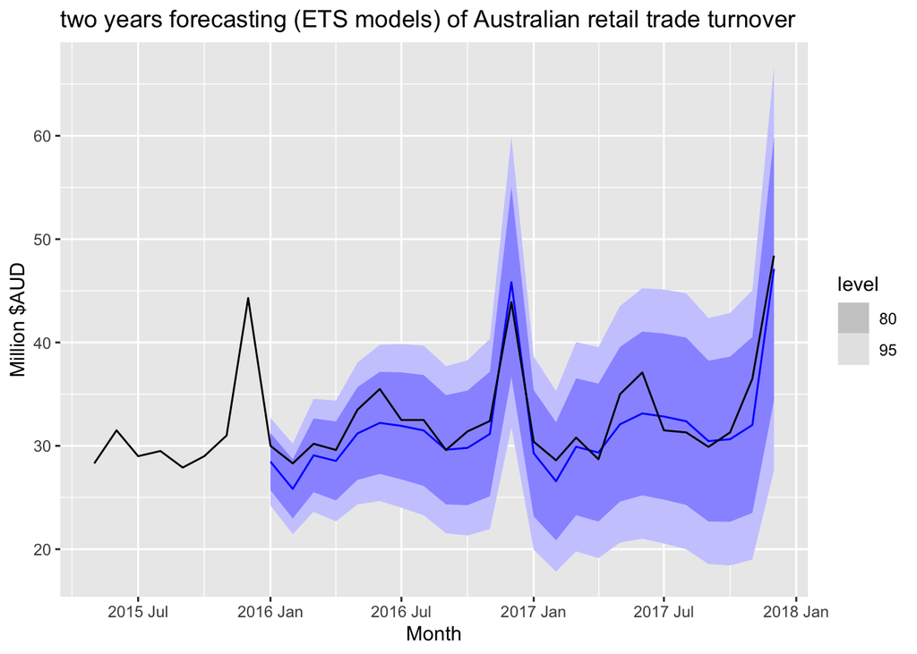

```r
pi_ets80<- list_ETS %>%
  forecast(h = "2 years") %>%
  hilo(80)

pi_ets95<- list_ETS %>%
  forecast(h = "2 years") %>%
  hilo(95)

train %>%
  model(MAM =  ETS(Turnover ~ error('M')+trend('A')+season('M')))%>%
  forecast(h = '2 years') %>%
  autoplot(slice_tail(myseries, n = 4*8)) +
  ggtitle("two years forecasting (ETS models) of Australian retail trade turnover") + ylab("Million $AUD")
```

##Forecasting via ARIMA model and prediction interval for 80% and 95%

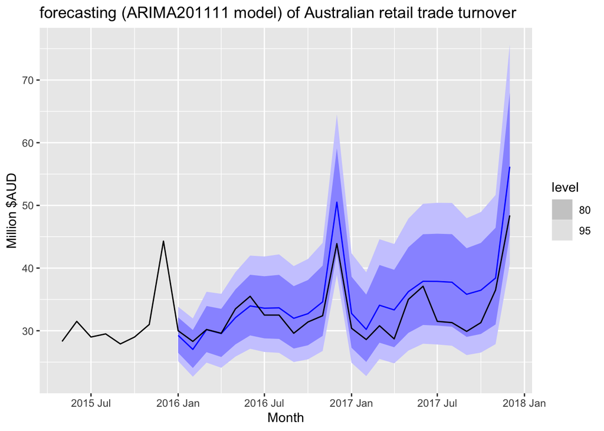

```r
pi_arima80<- list_ARIMA %>%
  forecast(h = "2 years") %>%
  hilo(80)

pi_arima95<- list_ARIMA %>%
  forecast(h = "2 years") %>%
  hilo(95)

train %>%
  model(arima201111 = ARIMA(log(Turnover) ~1+pdq(2,0,1)+PDQ(1,1,1)))%>%   forecast(h = '2 years') %>%
  autoplot(slice_tail(myseries, n = 4*8)) +
  ggtitle("forecasting (ARIMA201111 model) of Australian retail trade turnover") + ylab("Million $AUD")
```

##residual diagnostic, Ljung-box test fot ETS model

The line plot of residual of ETS model shows that the variance is not constant, and it might be Heteroskedasticity. The acf plot shows the residual is not a white noise, because except seasonal lag of 12, the non-seasonal lag of 22 is also have spike.That seems ETS model did not capture well for some non-seasonal information and seasonal information. The histogram indicated the residual is not that normality, because of the asymmetric and seems negative skewed.

To test the serial correlation. We conduct Ljung-box test. The null hypothesis:he data are independently distributed, against,the data are not independently distributed; they exhibit serial correlation. The p-value is almost 0, which is smaller than 5% significant level. In conclusion, we can reject the null hypothesis. The residual of ETS model have serial correlation.

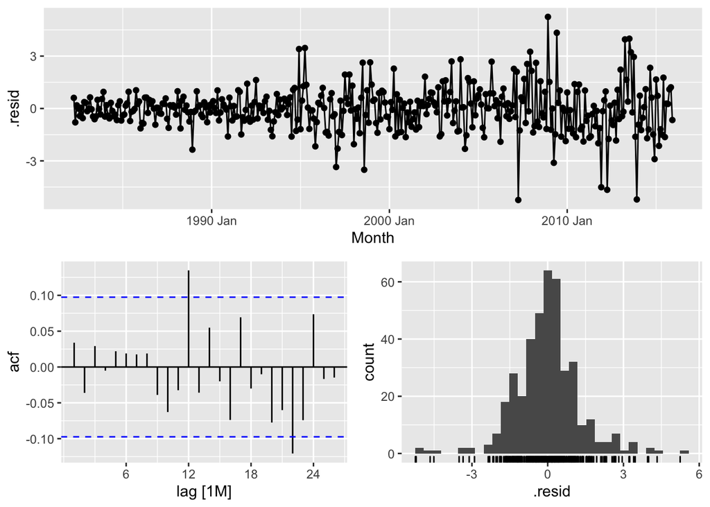

```r
fit %>%
  select(ets_mam) %>%
  augment() %>%
  gg_tsdisplay(.resid, plot_type = 'hist')
```

```r
fit %>%
  select(ets_mam) %>%
  augment() %>%
  features(.resid, ljung_box, lag = 24, dof = 16)
```

```
## # A tibble: 1 x 4
##   .model  lb_stat lb_pvalue .name_repair
##   <chr>     <dbl>     <dbl> <chr>
## 1 ets_mam    34.2 0.0000375 minimal
```

##residual diagnostic, Ljung-box test for ARIMA model The line plot of residuals of ARIMA model tells the variance of residual changes and seems Heteroskedasticity. And the acf plot is not white noise, only lag 3 is spike. The histogram looks  
asymmetric. And also not that normality.

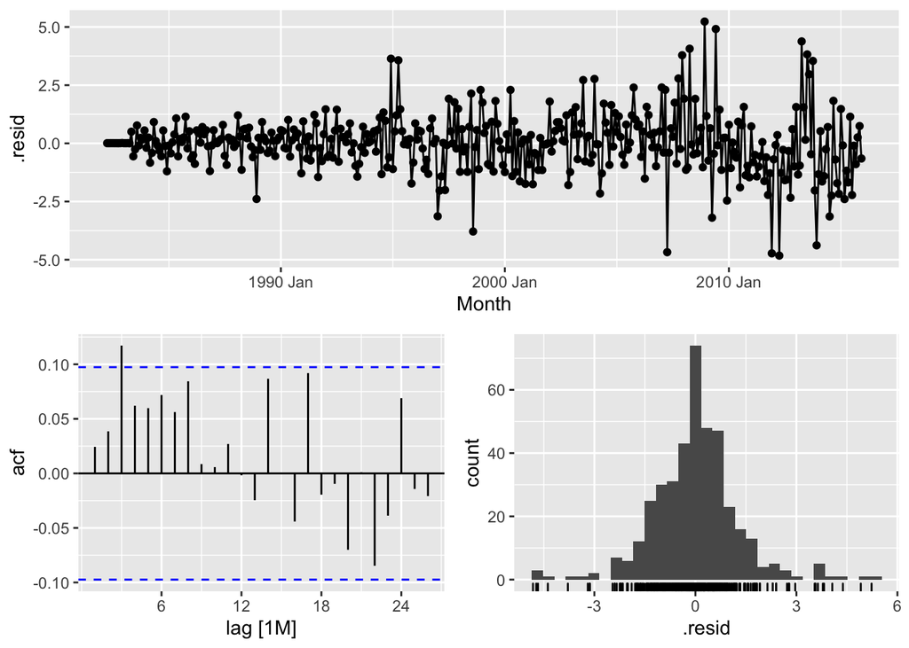

```r
fit %>%
  select(arima201111) %>%
    augment() %>%
  gg_tsdisplay(.resid, plot_type = 'hist')
```

```r
fit %>%
  select(arima201111) %>%
  augment() %>%
  features(.resid, ljung_box, lag = 24, dof = 6)
```

```
## # A tibble: 1 x 4
##   .model      lb_stat lb_pvalue .name_repair
##   <chr>         <dbl>     <dbl> <chr>
## 1 arima201111    32.2    0.0207 minimal
```

5. Comparison of the results from each of your preferred models. Which method do you think gives the better forecasts? Explain with reference to the test-set.

##model comparison The residuals of both models seems not white noise and do have serial correlations. The ETS(M,A,M) not well capture the seasonal and non-seasonal components of the data. While ARIMA(2,0,1)(1,1,1) seems better capturing seasonal component than ETS model.

Then use time series cross-validation for one step on the data to compare the accuracy, along with ETS(M,A,M) and ARIMA(2,0,1)(1,1,1). The result shows ETS(M,A,M) model has smaller RMSE than ARIMA model. And the accuracy for test-set shows the same result.

```r
cv_train<- train %>%
  slice(1:(n() - 1)) %>%
  stretch_tsibble(.init = 96, .step = 1)

cv_fc <- cv_train %>%
  model(ets_mam =  ETS(Turnover ~ error('M')+trend('A')+season('M')),
        arima201111 = ARIMA(log(Turnover) ~1+pdq(2,0,1)+PDQ(1,1,1))) %>%
  forecast(h = "2 years")
cv_fc %>%
  accuracy(myseries)
```

```
## # A tibble: 2 x 10
##   .model      .type     ME  RMSE   MAE    MPE  MAPE  MASE RMSSE  ACF1
##   <chr>       <chr>  <dbl> <dbl> <dbl>  <dbl> <dbl> <dbl> <dbl> <dbl>
## 1 arima201111 Test  -0.964  3.68  2.59 -5.55   12.6  1.27  1.32 0.827
## 2 ets_mam     Test   0.159  3.15  2.32 -0.390  11.5  1.14  1.13 0.805
```

```r
fit %>%
  forecast(h = "2 years") %>%
   accuracy(test)
```

```
## # A tibble: 2 x 10
##   .model      .type    ME  RMSE   MAE   MPE  MAPE  MASE RMSSE   ACF1
##   <chr>       <chr> <dbl> <dbl> <dbl> <dbl> <dbl> <dbl> <dbl>  <dbl>
## 1 arima201111 Test  -2.39  3.63  2.80 -7.07  8.38   NaN   NaN 0.486
## 2 ets_mam     Test   1.16  1.96  1.63  3.52  4.88   NaN   NaN 0.0860
```

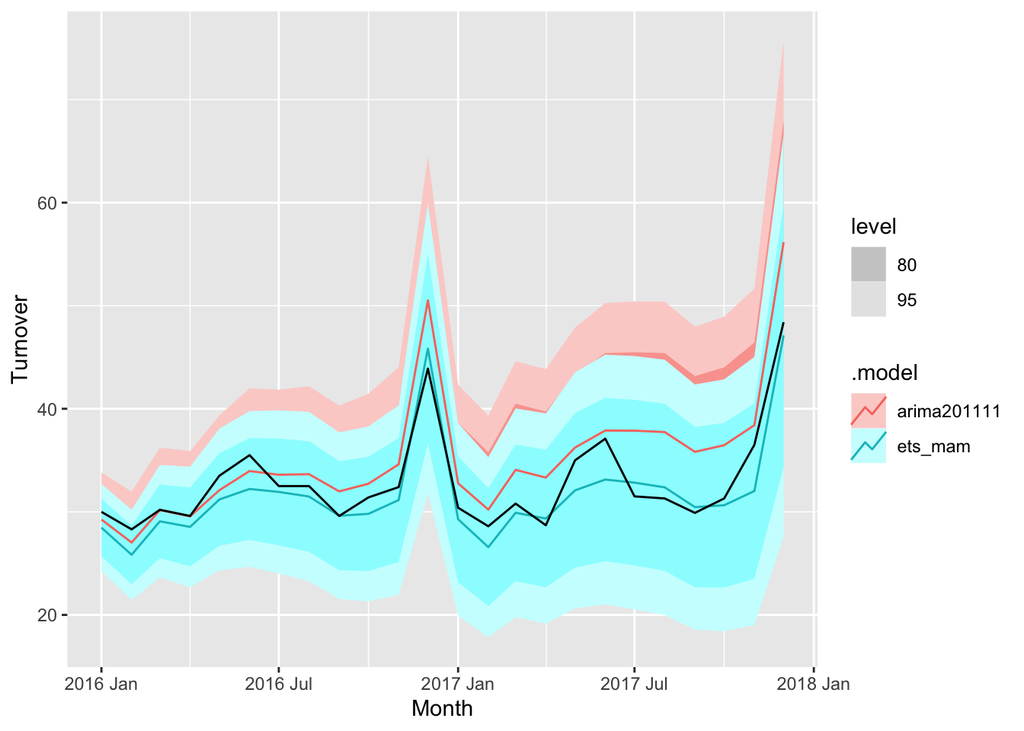

```r
fit %>%
  forecast(h = "2 years") %>%
  autoplot(test)
```

6. Apply your two chosen models to the full data set and produce out-of-sample point forecasts and 80% prediction intervals for each model for two years past the end of the data provided.

```r
all_fit <- myseries %>%
  model(ets_mam =  ETS(Turnover ~ error('M')+trend('A')+season('M')),
        arima201111 = ARIMA(log(Turnover) ~1+pdq(2,0,1)+PDQ(1,1,1)))

fc_all <- all_fit %>%
  forecast(h = "2 years")


fc_pi <- all_fit %>%
  forecast(h = "2 years") %>%
   hilo(80)   ##80% prediction intervals
```

7. Obtain up-to-date data from the ABS website (Cat. 8501.0, Table 11), and compare your forecasts with the actual numbers. How well did you do? [Hint: the readabs package can help in getting the data into R.]

##The smallet RMSE and MAE shows that ETS model performed better than ARIMA model when comparing with the up-to-date data for point forecast. While, for prediction interval and for the whole distribution ARIMA model performed better than ETS model,which have smallest winkler and CRPS.

```r
abs_data <- read_abs(series_id = unique(myseries$`Series ID`)) %>%
  transmute(Month = yearmonth(date), Turnover = value) %>%
  as_tsibble(index = Month)
```

```
## Finding URLs for tables corresponding to ABS series ID
```

```
## Attempting to download files from series ID , Retail Trade, Australia
```

```
## Extracting data from downloaded spreadsheets
```

```
## Tidying data from imported ABS spreadsheets
```

```r
abs<- abs_data %>%
  filter(Month >=yearmonth('2018 Jan'))

fc_all %>%
  accuracy(abs)
```

```
## # A tibble: 2 x 10
##   .model      .type    ME  RMSE   MAE   MPE  MAPE  MASE RMSSE  ACF1
##   <chr>       <chr> <dbl> <dbl> <dbl> <dbl> <dbl> <dbl> <dbl> <dbl>
## 1 arima201111 Test  -1.54  2.72  2.07 -4.14  5.53   NaN   NaN 0.354
## 2 ets_mam     Test   1.76  2.62  2.01  4.52  5.19   NaN   NaN 0.216
```

```r
fc_all %>%
  accuracy(abs_data, measures = interval_accuracy_measures)
```

```
## # A tibble: 2 x 3
##   .model      .type winkler
##   <chr>       <chr>   <dbl>
## 1 arima201111 Test     19.8
## 2 ets_mam     Test     21.2
```

```r
fc_all %>%
  accuracy(abs_data, measures = distribution_accuracy_measures)
```

```
## # A tibble: 2 x 4
##   .model      .type percentile  CRPS
##   <chr>       <chr>      <dbl> <dbl>
## 1 arima201111 Test        1.59  1.58
## 2 ets_mam     Test        1.73  1.71
```

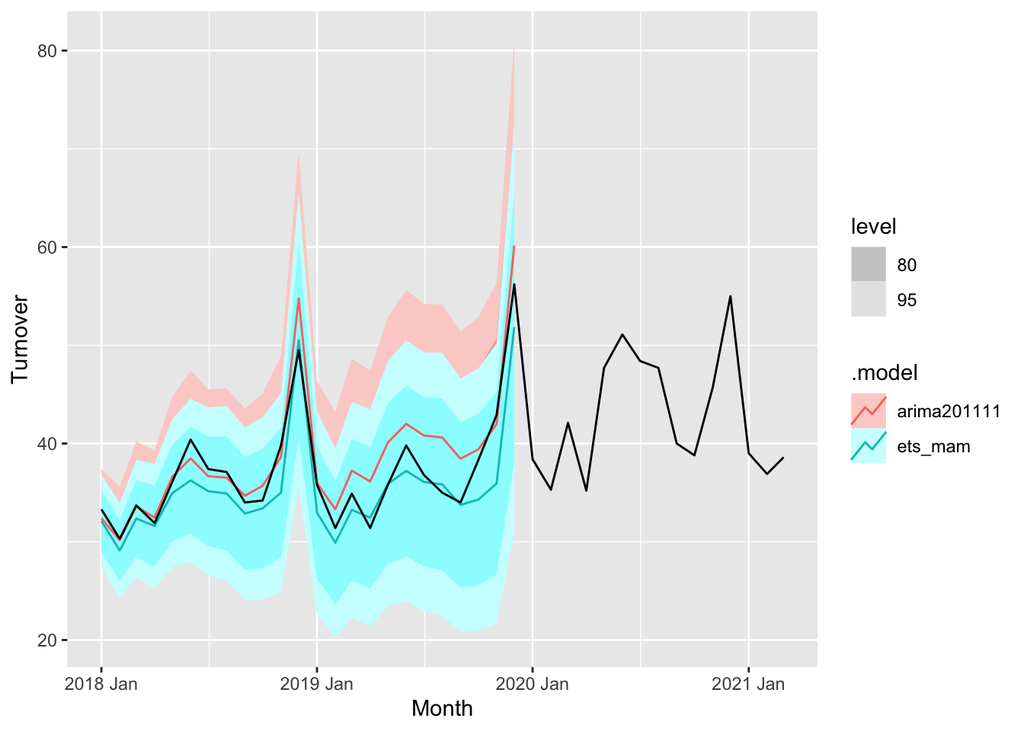

```r
fc_all %>%
  autoplot(abs)
```

8.A discussion of benefits and limitations of the models for your data.

##Linear exponential smoothing models are all special cases of ARIMA models, the non-linear exponential smoothing models have no equivalent ARIMA counterparts. And all ETS models are non-stationary, while some ARIMA models are stationary.